# examples_0114

Simplify the following powers of $i$.

- $i^{21}=$
- $i^{43}=$
- $i^{48}=$
- $i^{58}=$

For any positive integer $n$, we can evaluate $i^n$ by determining the remainder when $n$ is divided by 4.

| Remainder of $n/4$ | $i^n$ |
| --- | --- |
| 0 | $1$ |
| 1 | $i$ |
| 2 | $-1$ |
| 3 | $-i$ |

In computer programming, the [modulo operator](https://en.wikipedia.org/wiki/Modulo) returns the remainder. This operation is used so frequently, that it is often abbreviated to a single symbol (for example, in Python, `5%2` represents the remainder when 5 is divided by 2.)

I will represent the remainders using the [Desmos](https://www.desmos.com/calculator) notation.

- $\mathrm{mod}(21,4)=1$ so $i^{21}=i$
- $\mathrm{mod}(43,4)=3$ so $i^{43}=-i$
- $\mathrm{mod}(48,4)=0$ so $i^{48}=1$
- $\mathrm{mod}(58,4)=2$ so $i^{58}=-1$

To find the remainder using a scientific calculator, I would divide by 4, [floor](https://en.wikipedia.org/wiki/Floor_and_ceiling_functions) the result, multiply by 4, and subtract that amount from the original.

$$\mathrm{mod}(x,4)~=~x-4\cdot
\left\lfloor\frac{x}{4}\right\rfloor$$

Simplify the following powers of $i$.

- $i^{26}=$
- $i^{39}=$
- $i^{53}=$
- $i^{60}=$

For any positive integer $n$, we can evaluate $i^n$ by determining the remainder when $n$ is divided by 4.

| Remainder of $n/4$ | $i^n$ |
| --- | --- |
| 0 | $1$ |
| 1 | $i$ |
| 2 | $-1$ |
| 3 | $-i$ |

In computer programming, the [modulo operator](https://en.wikipedia.org/wiki/Modulo) returns the remainder. This operation is used so frequently, that it is often abbreviated to a single symbol (for example, in Python, `5%2` represents the remainder when 5 is divided by 2.)

I will represent the remainders using the [Desmos](https://www.desmos.com/calculator) notation.

- $\mathrm{mod}(26,4)=2$ so $i^{26}=-1$
- $\mathrm{mod}(39,4)=3$ so $i^{39}=-i$
- $\mathrm{mod}(53,4)=1$ so $i^{53}=i$
- $\mathrm{mod}(60,4)=0$ so $i^{60}=1$

To find the remainder using a scientific calculator, I would divide by 4, [floor](https://en.wikipedia.org/wiki/Floor_and_ceiling_functions) the result, multiply by 4, and subtract that amount from the original.

$$\mathrm{mod}(x,4)~=~x-4\cdot
\left\lfloor\frac{x}{4}\right\rfloor$$

Simplify the following powers of $i$.

- $i^{22}=$
- $i^{45}=$
- $i^{51}=$
- $i^{56}=$

For any positive integer $n$, we can evaluate $i^n$ by determining the remainder when $n$ is divided by 4.

| Remainder of $n/4$ | $i^n$ |
| --- | --- |
| 0 | $1$ |
| 1 | $i$ |
| 2 | $-1$ |
| 3 | $-i$ |

In computer programming, the [modulo operator](https://en.wikipedia.org/wiki/Modulo) returns the remainder. This operation is used so frequently, that it is often abbreviated to a single symbol (for example, in Python, `5%2` represents the remainder when 5 is divided by 2.)

I will represent the remainders using the [Desmos](https://www.desmos.com/calculator) notation.

- $\mathrm{mod}(22,4)=2$ so $i^{22}=-1$
- $\mathrm{mod}(45,4)=1$ so $i^{45}=i$
- $\mathrm{mod}(51,4)=3$ so $i^{51}=-i$
- $\mathrm{mod}(56,4)=0$ so $i^{56}=1$

To find the remainder using a scientific calculator, I would divide by 4, [floor](https://en.wikipedia.org/wiki/Floor_and_ceiling_functions) the result, multiply by 4, and subtract that amount from the original.

$$\mathrm{mod}(x,4)~=~x-4\cdot
\left\lfloor\frac{x}{4}\right\rfloor$$

Simplify the following powers of $i$.

- $i^{21}=$
- $i^{43}=$
- $i^{52}=$
- $i^{58}=$

For any positive integer $n$, we can evaluate $i^n$ by determining the remainder when $n$ is divided by 4.

| Remainder of $n/4$ | $i^n$ |
| --- | --- |
| 0 | $1$ |
| 1 | $i$ |
| 2 | $-1$ |
| 3 | $-i$ |

In computer programming, the [modulo operator](https://en.wikipedia.org/wiki/Modulo) returns the remainder. This operation is used so frequently, that it is often abbreviated to a single symbol (for example, in Python, `5%2` represents the remainder when 5 is divided by 2.)

I will represent the remainders using the [Desmos](https://www.desmos.com/calculator) notation.

- $\mathrm{mod}(21,4)=1$ so $i^{21}=i$
- $\mathrm{mod}(43,4)=3$ so $i^{43}=-i$
- $\mathrm{mod}(52,4)=0$ so $i^{52}=1$
- $\mathrm{mod}(58,4)=2$ so $i^{58}=-1$

To find the remainder using a scientific calculator, I would divide by 4, [floor](https://en.wikipedia.org/wiki/Floor_and_ceiling_functions) the result, multiply by 4, and subtract that amount from the original.

$$\mathrm{mod}(x,4)~=~x-4\cdot
\left\lfloor\frac{x}{4}\right\rfloor$$

Simplify the following powers of $i$.

- $i^{20}=$
- $i^{33}=$
- $i^{46}=$
- $i^{55}=$

For any positive integer $n$, we can evaluate $i^n$ by determining the remainder when $n$ is divided by 4.

| Remainder of $n/4$ | $i^n$ |
| --- | --- |
| 0 | $1$ |
| 1 | $i$ |
| 2 | $-1$ |
| 3 | $-i$ |

In computer programming, the [modulo operator](https://en.wikipedia.org/wiki/Modulo) returns the remainder. This operation is used so frequently, that it is often abbreviated to a single symbol (for example, in Python, `5%2` represents the remainder when 5 is divided by 2.)

I will represent the remainders using the [Desmos](https://www.desmos.com/calculator) notation.

- $\mathrm{mod}(20,4)=0$ so $i^{20}=1$
- $\mathrm{mod}(33,4)=1$ so $i^{33}=i$
- $\mathrm{mod}(46,4)=2$ so $i^{46}=-1$
- $\mathrm{mod}(55,4)=3$ so $i^{55}=-i$

To find the remainder using a scientific calculator, I would divide by 4, [floor](https://en.wikipedia.org/wiki/Floor_and_ceiling_functions) the result, multiply by 4, and subtract that amount from the original.

$$\mathrm{mod}(x,4)~=~x-4\cdot
\left\lfloor\frac{x}{4}\right\rfloor$$

Simplify the following powers of $i$.

- $i^{28}=$
- $i^{42}=$
- $i^{47}=$
- $i^{57}=$

For any positive integer $n$, we can evaluate $i^n$ by determining the remainder when $n$ is divided by 4.

| Remainder of $n/4$ | $i^n$ |
| --- | --- |
| 0 | $1$ |
| 1 | $i$ |
| 2 | $-1$ |
| 3 | $-i$ |

In computer programming, the [modulo operator](https://en.wikipedia.org/wiki/Modulo) returns the remainder. This operation is used so frequently, that it is often abbreviated to a single symbol (for example, in Python, `5%2` represents the remainder when 5 is divided by 2.)

I will represent the remainders using the [Desmos](https://www.desmos.com/calculator) notation.

- $\mathrm{mod}(28,4)=0$ so $i^{28}=1$
- $\mathrm{mod}(42,4)=2$ so $i^{42}=-1$
- $\mathrm{mod}(47,4)=3$ so $i^{47}=-i$
- $\mathrm{mod}(57,4)=1$ so $i^{57}=i$

To find the remainder using a scientific calculator, I would divide by 4, [floor](https://en.wikipedia.org/wiki/Floor_and_ceiling_functions) the result, multiply by 4, and subtract that amount from the original.

$$\mathrm{mod}(x,4)~=~x-4\cdot
\left\lfloor\frac{x}{4}\right\rfloor$$

Simplify the following powers of $i$.

- $i^{21}=$
- $i^{43}=$
- $i^{54}=$
- $i^{60}=$

For any positive integer $n$, we can evaluate $i^n$ by determining the remainder when $n$ is divided by 4.

| Remainder of $n/4$ | $i^n$ |
| --- | --- |
| 0 | $1$ |
| 1 | $i$ |
| 2 | $-1$ |
| 3 | $-i$ |

In computer programming, the [modulo operator](https://en.wikipedia.org/wiki/Modulo) returns the remainder. This operation is used so frequently, that it is often abbreviated to a single symbol (for example, in Python, `5%2` represents the remainder when 5 is divided by 2.)

I will represent the remainders using the [Desmos](https://www.desmos.com/calculator) notation.

- $\mathrm{mod}(21,4)=1$ so $i^{21}=i$
- $\mathrm{mod}(43,4)=3$ so $i^{43}=-i$
- $\mathrm{mod}(54,4)=2$ so $i^{54}=-1$
- $\mathrm{mod}(60,4)=0$ so $i^{60}=1$

To find the remainder using a scientific calculator, I would divide by 4, [floor](https://en.wikipedia.org/wiki/Floor_and_ceiling_functions) the result, multiply by 4, and subtract that amount from the original.

$$\mathrm{mod}(x,4)~=~x-4\cdot
\left\lfloor\frac{x}{4}\right\rfloor$$

Simplify the following powers of $i$.

- $i^{25}=$
- $i^{39}=$
- $i^{50}=$
- $i^{56}=$

For any positive integer $n$, we can evaluate $i^n$ by determining the remainder when $n$ is divided by 4.

| Remainder of $n/4$ | $i^n$ |
| --- | --- |
| 0 | $1$ |
| 1 | $i$ |
| 2 | $-1$ |
| 3 | $-i$ |

In computer programming, the [modulo operator](https://en.wikipedia.org/wiki/Modulo) returns the remainder. This operation is used so frequently, that it is often abbreviated to a single symbol (for example, in Python, `5%2` represents the remainder when 5 is divided by 2.)

I will represent the remainders using the [Desmos](https://www.desmos.com/calculator) notation.

- $\mathrm{mod}(25,4)=1$ so $i^{25}=i$
- $\mathrm{mod}(39,4)=3$ so $i^{39}=-i$
- $\mathrm{mod}(50,4)=2$ so $i^{50}=-1$
- $\mathrm{mod}(56,4)=0$ so $i^{56}=1$

To find the remainder using a scientific calculator, I would divide by 4, [floor](https://en.wikipedia.org/wiki/Floor_and_ceiling_functions) the result, multiply by 4, and subtract that amount from the original.

$$\mathrm{mod}(x,4)~=~x-4\cdot
\left\lfloor\frac{x}{4}\right\rfloor$$

Simplify the following powers of $i$.

- $i^{37}=$
- $i^{46}=$
- $i^{55}=$
- $i^{60}=$

For any positive integer $n$, we can evaluate $i^n$ by determining the remainder when $n$ is divided by 4.

| Remainder of $n/4$ | $i^n$ |
| --- | --- |
| 0 | $1$ |
| 1 | $i$ |
| 2 | $-1$ |
| 3 | $-i$ |

In computer programming, the [modulo operator](https://en.wikipedia.org/wiki/Modulo) returns the remainder. This operation is used so frequently, that it is often abbreviated to a single symbol (for example, in Python, `5%2` represents the remainder when 5 is divided by 2.)

I will represent the remainders using the [Desmos](https://www.desmos.com/calculator) notation.

- $\mathrm{mod}(37,4)=1$ so $i^{37}=i$
- $\mathrm{mod}(46,4)=2$ so $i^{46}=-1$
- $\mathrm{mod}(55,4)=3$ so $i^{55}=-i$
- $\mathrm{mod}(60,4)=0$ so $i^{60}=1$

To find the remainder using a scientific calculator, I would divide by 4, [floor](https://en.wikipedia.org/wiki/Floor_and_ceiling_functions) the result, multiply by 4, and subtract that amount from the original.

$$\mathrm{mod}(x,4)~=~x-4\cdot
\left\lfloor\frac{x}{4}\right\rfloor$$

Simplify the following powers of $i$.

- $i^{25}=$
- $i^{44}=$
- $i^{50}=$
- $i^{59}=$

For any positive integer $n$, we can evaluate $i^n$ by determining the remainder when $n$ is divided by 4.

| Remainder of $n/4$ | $i^n$ |
| --- | --- |
| 0 | $1$ |
| 1 | $i$ |
| 2 | $-1$ |
| 3 | $-i$ |

In computer programming, the [modulo operator](https://en.wikipedia.org/wiki/Modulo) returns the remainder. This operation is used so frequently, that it is often abbreviated to a single symbol (for example, in Python, `5%2` represents the remainder when 5 is divided by 2.)

I will represent the remainders using the [Desmos](https://www.desmos.com/calculator) notation.

- $\mathrm{mod}(25,4)=1$ so $i^{25}=i$
- $\mathrm{mod}(44,4)=0$ so $i^{44}=1$
- $\mathrm{mod}(50,4)=2$ so $i^{50}=-1$
- $\mathrm{mod}(59,4)=3$ so $i^{59}=-i$

To find the remainder using a scientific calculator, I would divide by 4, [floor](https://en.wikipedia.org/wiki/Floor_and_ceiling_functions) the result, multiply by 4, and subtract that amount from the original.

$$\mathrm{mod}(x,4)~=~x-4\cdot
\left\lfloor\frac{x}{4}\right\rfloor$$

The solutions to $x^{2}+{10}x-{83}=0$ can be expressed, in simplest form, as $x=h\pm p\sqrt{q}$, where $p$ might be [imaginary](https://en.wikipedia.org/wiki/Imaginary_number). Find the values of $h$, $p$, and $q$.

$h=$

$p=$

$q=$

Write the equation.

$$x^{2}+{10}x-{83}=0$$

Identify the coefficients.

$$a=1$$
$$b=10$$
$$c=-83$$

Plug numbers into the quadratic formula.

$$x =
\frac{-(10)\pm\sqrt{(10)^2-4(1)(-83)}}{2(1)}$$

Simplify.

$$x = \frac{-10 \pm
\sqrt{100-(-332)}}{2}$$

Simplify.

$$x = \frac{-10 \pm
\sqrt{432}}{2}$$

Use prime factorization.

$$x = \frac{-10 \pm
\sqrt{2\cdot2\cdot2\cdot2\cdot3\cdot3\cdot3}}{2}$$

Isolate the twin factors.

$$x = \frac{-10 \pm
\sqrt{2\cdot2\cdot2\cdot2\cdot3\cdot3}\cdot \sqrt{3}}{2}$$

Simplify the square root of the square.

$$x = \frac{-10 \pm 2\cdot2\cdot3\cdot
\sqrt{3}}{2}$$

Simplify the integer products.

$$x = \frac{-10 \pm 12\cdot
\sqrt{3}}{2}$$

Split the fraction.

$$x = \frac{-10}{2} \pm \frac{12\cdot
\sqrt{3}}{2}$$

Both numerators contain a factor of 2.

$$x = -5 \pm 6\sqrt{3}$$

So, $h=-5$ and $p=6$ and $q=3$.

The solutions to $x^{2}-{16}x+{32}=0$ can be expressed, in simplest form, as $x=h\pm p\sqrt{q}$, where $p$ might be [imaginary](https://en.wikipedia.org/wiki/Imaginary_number). Find the values of $h$, $p$, and $q$.

$h=$

$p=$

$q=$

Write the equation.

$$x^{2}-{16}x+{32}=0$$

Identify the coefficients.

$$a=1$$
$$b=-16$$
$$c=32$$

Plug numbers into the quadratic formula.

$$x =
\frac{-(-16)\pm\sqrt{(-16)^2-4(1)(32)}}{2(1)}$$

Simplify.

$$x = \frac{16 \pm
\sqrt{256-(128)}}{2}$$

Simplify.

$$x = \frac{16 \pm
\sqrt{128}}{2}$$

Use prime factorization.

$$x = \frac{16 \pm
\sqrt{2\cdot2\cdot2\cdot2\cdot2\cdot2\cdot2}}{2}$$

Isolate the twin factors.

$$x = \frac{16 \pm
\sqrt{2\cdot2\cdot2\cdot2\cdot2\cdot2}\cdot \sqrt{2}}{2}$$

Simplify the square root of the square.

$$x = \frac{16 \pm 2\cdot2\cdot2\cdot
\sqrt{2}}{2}$$

Simplify the integer products.

$$x = \frac{16 \pm 8\cdot
\sqrt{2}}{2}$$

Split the fraction.

$$x = \frac{16}{2} \pm \frac{8\cdot
\sqrt{2}}{2}$$

Both numerators contain a factor of 2.

$$x = 8 \pm 4\sqrt{2}$$

So, $h=8$ and $p=4$ and $q=2$.

The solutions to $x^{2}+{10}x+1=0$ can be expressed, in simplest form, as $x=h\pm p\sqrt{q}$, where $p$ might be [imaginary](https://en.wikipedia.org/wiki/Imaginary_number). Find the values of $h$, $p$, and $q$.

$h=$

$p=$

$q=$

Write the equation.

$$x^{2}+{10}x+1=0$$

Identify the coefficients.

$$a=1$$
$$b=10$$
$$c=1$$

Plug numbers into the quadratic formula.

$$x =
\frac{-(10)\pm\sqrt{(10)^2-4(1)(1)}}{2(1)}$$

Simplify.

$$x = \frac{-10 \pm
\sqrt{100-(4)}}{2}$$

Simplify.

$$x = \frac{-10 \pm
\sqrt{96}}{2}$$

Use prime factorization.

$$x = \frac{-10 \pm
\sqrt{2\cdot2\cdot2\cdot2\cdot2\cdot3}}{2}$$

Isolate the twin factors.

$$x = \frac{-10 \pm
\sqrt{2\cdot2\cdot2\cdot2}\cdot \sqrt{2\cdot3}}{2}$$

Simplify the square root of the square.

$$x = \frac{-10 \pm 2\cdot2\cdot
\sqrt{2\cdot3}}{2}$$

Simplify the integer products.

$$x = \frac{-10 \pm 4\cdot
\sqrt{6}}{2}$$

Split the fraction.

$$x = \frac{-10}{2} \pm \frac{4\cdot
\sqrt{6}}{2}$$

Both numerators contain a factor of 2.

$$x = -5 \pm 2\sqrt{6}$$

So, $h=-5$ and $p=2$ and $q=6$.

The solutions to $x^{2}-{16}x+{19}=0$ can be expressed, in simplest form, as $x=h\pm p\sqrt{q}$, where $p$ might be [imaginary](https://en.wikipedia.org/wiki/Imaginary_number). Find the values of $h$, $p$, and $q$.

$h=$

$p=$

$q=$

Write the equation.

$$x^{2}-{16}x+{19}=0$$

Identify the coefficients.

$$a=1$$
$$b=-16$$
$$c=19$$

Plug numbers into the quadratic formula.

$$x =
\frac{-(-16)\pm\sqrt{(-16)^2-4(1)(19)}}{2(1)}$$

Simplify.

$$x = \frac{16 \pm
\sqrt{256-(76)}}{2}$$

Simplify.

$$x = \frac{16 \pm
\sqrt{180}}{2}$$

Use prime factorization.

$$x = \frac{16 \pm
\sqrt{2\cdot2\cdot3\cdot3\cdot5}}{2}$$

Isolate the twin factors.

$$x = \frac{16 \pm
\sqrt{2\cdot2\cdot3\cdot3}\cdot \sqrt{5}}{2}$$

Simplify the square root of the square.

$$x = \frac{16 \pm 2\cdot3\cdot
\sqrt{5}}{2}$$

Simplify the integer products.

$$x = \frac{16 \pm 6\cdot
\sqrt{5}}{2}$$

Split the fraction.

$$x = \frac{16}{2} \pm \frac{6\cdot
\sqrt{5}}{2}$$

Both numerators contain a factor of 2.

$$x = 8 \pm 3\sqrt{5}$$

So, $h=8$ and $p=3$ and $q=5$.

The solutions to $x^{2}+{18}x+{156}=0$ can be expressed, in simplest form, as $x=h\pm p\sqrt{q}$, where $p$ might be [imaginary](https://en.wikipedia.org/wiki/Imaginary_number). Find the values of $h$, $p$, and $q$.

$h=$

$p=$

$q=$

Write the equation.

$$x^{2}+{18}x+{156}=0$$

Identify the coefficients.

$$a=1$$
$$b=18$$
$$c=156$$

Plug numbers into the quadratic formula.

$$x =
\frac{-(18)\pm\sqrt{(18)^2-4(1)(156)}}{2(1)}$$

Simplify.

$$x = \frac{-18 \pm
\sqrt{324-624}}{2}$$

Simplify.

$$x = \frac{-18 \pm
\sqrt{-300}}{2}$$

Use prime factorization.

$$x = \frac{-18 \pm
\sqrt{(-1)\cdot2\cdot2\cdot3\cdot5\cdot5}}{2}$$

Isolate the twin factors.

$$x = \frac{-18 \pm
\sqrt{2\cdot2\cdot5\cdot5}\cdot\sqrt{-1} \cdot \sqrt{3}}{2}$$

Simplify the square root of the square.

$$x = \frac{-18 \pm 2\cdot5\cdot i \cdot
\sqrt{3}}{2}$$

Simplify the integer products.

$$x = \frac{-18 \pm 10i
\sqrt{3}}{2}$$

Split the fraction.

$$x = \frac{-18}{2} \pm
\frac{10i\sqrt{3}}{2}$$

Both numerators contain a factor of 2.

$$x = -9 \pm 5i\sqrt{3}$$

So, $h=-9$ and $p=5i$ and $q=3$.

The solutions to $x^{2}-{18}x+{231}=0$ can be expressed, in simplest form, as $x=h\pm p\sqrt{q}$, where $p$ might be [imaginary](https://en.wikipedia.org/wiki/Imaginary_number). Find the values of $h$, $p$, and $q$.

$h=$

$p=$

$q=$

Write the equation.

$$x^{2}-{18}x+{231}=0$$

Identify the coefficients.

$$a=1$$
$$b=-18$$
$$c=231$$

Plug numbers into the quadratic formula.

$$x =
\frac{-(-18)\pm\sqrt{(-18)^2-4(1)(231)}}{2(1)}$$

Simplify.

$$x = \frac{18 \pm
\sqrt{324-924}}{2}$$

Simplify.

$$x = \frac{18 \pm
\sqrt{-600}}{2}$$

Use prime factorization.

$$x = \frac{18 \pm
\sqrt{(-1)\cdot2\cdot2\cdot2\cdot3\cdot5\cdot5}}{2}$$

Isolate the twin factors.

$$x = \frac{18 \pm
\sqrt{2\cdot2\cdot5\cdot5}\cdot\sqrt{-1} \cdot
\sqrt{2\cdot3}}{2}$$

Simplify the square root of the square.

$$x = \frac{18 \pm 2\cdot5\cdot i \cdot
\sqrt{2\cdot3}}{2}$$

Simplify the integer products.

$$x = \frac{18 \pm 10i
\sqrt{6}}{2}$$

Split the fraction.

$$x = \frac{18}{2} \pm
\frac{10i\sqrt{6}}{2}$$

Both numerators contain a factor of 2.

$$x = 9 \pm 5i\sqrt{6}$$

So, $h=9$ and $p=5i$ and $q=6$.

The solutions to $x^{2}+{10}x+{150}=0$ can be expressed, in simplest form, as $x=h\pm p\sqrt{q}$, where $p$ might be [imaginary](https://en.wikipedia.org/wiki/Imaginary_number). Find the values of $h$, $p$, and $q$.

$h=$

$p=$

$q=$

Write the equation.

$$x^{2}+{10}x+{150}=0$$

Identify the coefficients.

$$a=1$$
$$b=10$$
$$c=150$$

Plug numbers into the quadratic formula.

$$x =
\frac{-(10)\pm\sqrt{(10)^2-4(1)(150)}}{2(1)}$$

Simplify.

$$x = \frac{-10 \pm
\sqrt{100-600}}{2}$$

Simplify.

$$x = \frac{-10 \pm
\sqrt{-500}}{2}$$

Use prime factorization.

$$x = \frac{-10 \pm
\sqrt{(-1)\cdot2\cdot2\cdot5\cdot5\cdot5}}{2}$$

Isolate the twin factors.

$$x = \frac{-10 \pm
\sqrt{2\cdot2\cdot5\cdot5}\cdot\sqrt{-1} \cdot \sqrt{5}}{2}$$

Simplify the square root of the square.

$$x = \frac{-10 \pm 2\cdot5\cdot i \cdot
\sqrt{5}}{2}$$

Simplify the integer products.

$$x = \frac{-10 \pm 10i
\sqrt{5}}{2}$$

Split the fraction.

$$x = \frac{-10}{2} \pm
\frac{10i\sqrt{5}}{2}$$

Both numerators contain a factor of 2.

$$x = -5 \pm 5i\sqrt{5}$$

So, $h=-5$ and $p=5i$ and $q=5$.

The solutions to $x^{2}-{14}x+{409}=0$ can be expressed, in simplest form, as $x=h\pm p\sqrt{q}$, where $p$ might be [imaginary](https://en.wikipedia.org/wiki/Imaginary_number). Find the values of $h$, $p$, and $q$.

$h=$

$p=$

$q=$

Write the equation.

$$x^{2}-{14}x+{409}=0$$

Identify the coefficients.

$$a=1$$
$$b=-14$$
$$c=409$$

Plug numbers into the quadratic formula.

$$x =
\frac{-(-14)\pm\sqrt{(-14)^2-4(1)(409)}}{2(1)}$$

Simplify.

$$x = \frac{14 \pm
\sqrt{196-1636}}{2}$$

Simplify.

$$x = \frac{14 \pm
\sqrt{-1440}}{2}$$

Use prime factorization.

$$x = \frac{14 \pm
\sqrt{(-1)\cdot2\cdot2\cdot2\cdot2\cdot2\cdot3\cdot3\cdot5}}{2}$$

Isolate the twin factors.

$$x = \frac{14 \pm
\sqrt{2\cdot2\cdot2\cdot2\cdot3\cdot3}\cdot\sqrt{-1} \cdot
\sqrt{2\cdot5}}{2}$$

Simplify the square root of the square.

$$x = \frac{14 \pm 2\cdot2\cdot3\cdot i
\cdot \sqrt{2\cdot5}}{2}$$

Simplify the integer products.

$$x = \frac{14 \pm 12i
\sqrt{10}}{2}$$

Split the fraction.

$$x = \frac{14}{2} \pm
\frac{12i\sqrt{10}}{2}$$

Both numerators contain a factor of 2.

$$x = 7 \pm 6i\sqrt{10}$$

So, $h=7$ and $p=6i$ and $q=10$.

The solutions to $x^{2}+{4}x-{44}=0$ can be expressed, in simplest form, as $x=h\pm p\sqrt{q}$, where $p$ might be [imaginary](https://en.wikipedia.org/wiki/Imaginary_number). Find the values of $h$, $p$, and $q$.

$h=$

$p=$

$q=$

Write the equation.

$$x^{2}+{4}x-{44}=0$$

Identify the coefficients.

$$a=1$$
$$b=4$$
$$c=-44$$

Plug numbers into the quadratic formula.

$$x =
\frac{-(4)\pm\sqrt{(4)^2-4(1)(-44)}}{2(1)}$$

Simplify.

$$x = \frac{-4 \pm
\sqrt{16-(-176)}}{2}$$

Simplify.

$$x = \frac{-4 \pm
\sqrt{192}}{2}$$

Use prime factorization.

$$x = \frac{-4 \pm
\sqrt{2\cdot2\cdot2\cdot2\cdot2\cdot2\cdot3}}{2}$$

Isolate the twin factors.

$$x = \frac{-4 \pm
\sqrt{2\cdot2\cdot2\cdot2\cdot2\cdot2}\cdot \sqrt{3}}{2}$$

Simplify the square root of the square.

$$x = \frac{-4 \pm 2\cdot2\cdot2\cdot
\sqrt{3}}{2}$$

Simplify the integer products.

$$x = \frac{-4 \pm 8\cdot
\sqrt{3}}{2}$$

Split the fraction.

$$x = \frac{-4}{2} \pm \frac{8\cdot
\sqrt{3}}{2}$$

Both numerators contain a factor of 2.

$$x = -2 \pm 4\sqrt{3}$$

So, $h=-2$ and $p=4$ and $q=3$.

The solutions to $x^{2}+{6}x-{151}=0$ can be expressed, in simplest form, as $x=h\pm p\sqrt{q}$, where $p$ might be [imaginary](https://en.wikipedia.org/wiki/Imaginary_number). Find the values of $h$, $p$, and $q$.

$h=$

$p=$

$q=$

Write the equation.

$$x^{2}+{6}x-{151}=0$$

Identify the coefficients.

$$a=1$$
$$b=6$$
$$c=-151$$

Plug numbers into the quadratic formula.

$$x =
\frac{-(6)\pm\sqrt{(6)^2-4(1)(-151)}}{2(1)}$$

Simplify.

$$x = \frac{-6 \pm
\sqrt{36-(-604)}}{2}$$

Simplify.

$$x = \frac{-6 \pm
\sqrt{640}}{2}$$

Use prime factorization.

$$x = \frac{-6 \pm
\sqrt{2\cdot2\cdot2\cdot2\cdot2\cdot2\cdot2\cdot5}}{2}$$

Isolate the twin factors.

$$x = \frac{-6 \pm
\sqrt{2\cdot2\cdot2\cdot2\cdot2\cdot2}\cdot
\sqrt{2\cdot5}}{2}$$

Simplify the square root of the square.

$$x = \frac{-6 \pm 2\cdot2\cdot2\cdot
\sqrt{2\cdot5}}{2}$$

Simplify the integer products.

$$x = \frac{-6 \pm 8\cdot
\sqrt{10}}{2}$$

Split the fraction.

$$x = \frac{-6}{2} \pm \frac{8\cdot
\sqrt{10}}{2}$$

Both numerators contain a factor of 2.

$$x = -3 \pm 4\sqrt{10}$$

So, $h=-3$ and $p=4$ and $q=10$.

Find the sum of the two [complex numbers](https://en.wikipedia.org/wiki/Complex_number).

$$(1-9i)+(-2-7i)$$

For addition, just add the real components $(1)+(-2)=-1$ and the imaginary components $(-9)+(-7)=-16$. Then, type your answer:
$$-1-16i$$

Find the difference of the two [complex numbers](https://en.wikipedia.org/wiki/Complex_number).

$$(-2-4i)-(6+6i)$$

For subtraction, just subtract the real components $(-2)-(6)=-8$ and the imaginary components $(-4)-(6)=-10$. Then, type your answer:
$$-8-10i$$

Find the difference of the two [complex numbers](https://en.wikipedia.org/wiki/Complex_number).

$$(-5-7i)-(-1+7i)$$

For subtraction, just subtract the real components $(-5)-(-1)=-4$ and the imaginary components $(-7)-(7)=-14$. Then, type your answer:
$$-4-14i$$

Find the sum of the two [complex numbers](https://en.wikipedia.org/wiki/Complex_number).

$$(-9+2i)+(1-8i)$$

For addition, just add the real components $(-9)+(1)=-8$ and the imaginary components $(2)+(-8)=-6$. Then, type your answer:
$$-8-6i$$

Find the difference of the two [complex numbers](https://en.wikipedia.org/wiki/Complex_number).

$$(-7+i)-(-6-i)$$

For subtraction, just subtract the real components $(-7)-(-6)=-1$ and the imaginary components $(1)-(-1)=2$. Then, type your answer:
$$-1+2i$$

Find the sum of the two [complex numbers](https://en.wikipedia.org/wiki/Complex_number).

$$(1+2i)+(6-8i)$$

For addition, just add the real components $(1)+(6)=7$ and the imaginary components $(2)+(-8)=-6$. Then, type your answer:
$$7-6i$$

Find the sum of the two [complex numbers](https://en.wikipedia.org/wiki/Complex_number).

$$(9-2i)+(4+9i)$$

For addition, just add the real components $(9)+(4)=13$ and the imaginary components $(-2)+(9)=7$. Then, type your answer:
$$13+7i$$

Find the sum of the two [complex numbers](https://en.wikipedia.org/wiki/Complex_number).

$$(3+2i)+(5-3i)$$

For addition, just add the real components $(3)+(5)=8$ and the imaginary components $(2)+(-3)=-1$. Then, type your answer:
$$8-i$$

Find the difference of the two [complex numbers](https://en.wikipedia.org/wiki/Complex_number).

$$(9-8i)-(-1-4i)$$

For subtraction, just subtract the real components $(9)-(-1)=10$ and the imaginary components $(-8)-(-4)=-4$. Then, type your answer:
$$10-4i$$

Find the difference of the two [complex numbers](https://en.wikipedia.org/wiki/Complex_number).

$$(2-3i)-(-3+9i)$$

For subtraction, just subtract the real components $(2)-(-3)=5$ and the imaginary components $(-3)-(9)=-12$. Then, type your answer:
$$5-12i$$

Find the product.
$$(9+2i) \cdot
(2-5i)$$

To multiply complex numbers, follow a procedure similar to [FOIL](https://en.wikipedia.org/wiki/FOIL_method), but remember $i^2=-1$.

$$(9+2i)(2-5i)$$

$$\Big((9)+(2i)\Big)\Big((2)+(-5i)\Big)$$

$$(9)(2)~~+~~(9)(-5i)~~+~~(2i)(2)~~+~~(2i)(-5i)$$
$$18~~+~~(-45)i~~+~~(4)i
~~+~~(-10)i^2$$

You could also use a box to multiply.

| * | $9$ | $2i$ |
| --- | --- | --- |
| $2$ | $18$ | $4i$ |
| $-5i$ | $-45i$ | $-10i^2$ |

$$18~~+~~(-45)i~~+~~(4)i
~~+~~(-10)i^2$$

Remember that $i^2=-1$.

$$18~~+~~(-45)i~~+~~(4)i~~+~~(10)$$

Let's group similar terms. We put the real terms to the left and the imaginary terms to the right.

$$18~~+~~(10)~~+~~(-45)i~~+~~(4)i$$
Combine the real terms and combine the imaginary terms.

$$28-41i$$

Find the product.
$$(-7+8i) \cdot
(-4-5i)$$

To multiply complex numbers, follow a procedure similar to [FOIL](https://en.wikipedia.org/wiki/FOIL_method), but remember $i^2=-1$.

$$(-7+8i)(-4-5i)$$

$$\Big((-7)+(8i)\Big)\Big((-4)+(-5i)\Big)$$

$$(-7)(-4)~~+~~(-7)(-5i)~~+~~(8i)(-4)~~+~~(8i)(-5i)$$
$$28~~+~~(35)i~~+~~(-32)i
~~+~~(-40)i^2$$

You could also use a box to multiply.

| * | $-7$ | $8i$ |
| --- | --- | --- |
| $-4$ | $28$ | $-32i$ |
| $-5i$ | $35i$ | $-40i^2$ |

$$28~~+~~(35)i~~+~~(-32)i
~~+~~(-40)i^2$$

Remember that $i^2=-1$.

$$28~~+~~(35)i~~+~~(-32)i~~+~~(40)$$

Let's group similar terms. We put the real terms to the left and the imaginary terms to the right.

$$28~~+~~(40)~~+~~(35)i~~+~~(-32)i$$
Combine the real terms and combine the imaginary terms.

$$68+3i$$

Find the product.
$$(1-4i) \cdot
(-8-8i)$$

To multiply complex numbers, follow a procedure similar to [FOIL](https://en.wikipedia.org/wiki/FOIL_method), but remember $i^2=-1$.

$$(1-4i)(-8-8i)$$

$$\Big((1)+(-4i)\Big)\Big((-8)+(-8i)\Big)$$

$$(1)(-8)~~+~~(1)(-8i)~~+~~(-4i)(-8)~~+~~(-4i)(-8i)$$
$$-8~~+~~(-8)i~~+~~(32)i
~~+~~(32)i^2$$

You could also use a box to multiply.

| * | $1$ | $-4i$ |
| --- | --- | --- |
| $-8$ | $-8$ | $32i$ |
| $-8i$ | $-8i$ | $32i^2$ |

$$-8~~+~~(-8)i~~+~~(32)i
~~+~~(32)i^2$$

Remember that $i^2=-1$.

$$-8~~+~~(-8)i~~+~~(32)i~~+~~(-32)$$

Let's group similar terms. We put the real terms to the left and the imaginary terms to the right.

$$-8~~+~~(-32)~~+~~(-8)i~~+~~(32)i$$
Combine the real terms and combine the imaginary terms.

$$-40+24i$$

Find the product.
$$(9-8i) \cdot
(3-6i)$$

To multiply complex numbers, follow a procedure similar to [FOIL](https://en.wikipedia.org/wiki/FOIL_method), but remember $i^2=-1$.

$$(9-8i)(3-6i)$$

$$\Big((9)+(-8i)\Big)\Big((3)+(-6i)\Big)$$

$$(9)(3)~~+~~(9)(-6i)~~+~~(-8i)(3)~~+~~(-8i)(-6i)$$
$$27~~+~~(-54)i~~+~~(-24)i
~~+~~(48)i^2$$

You could also use a box to multiply.

| * | $9$ | $-8i$ |
| --- | --- | --- |
| $3$ | $27$ | $-24i$ |
| $-6i$ | $-54i$ | $48i^2$ |

$$27~~+~~(-54)i~~+~~(-24)i
~~+~~(48)i^2$$

Remember that $i^2=-1$.

$$27~~+~~(-54)i~~+~~(-24)i~~+~~(-48)$$

Let's group similar terms. We put the real terms to the left and the imaginary terms to the right.

$$27~~+~~(-48)~~+~~(-54)i~~+~~(-24)i$$
Combine the real terms and combine the imaginary terms.

$$-21-78i$$

Find the product.
$$(7-i) \cdot
(9+3i)$$

To multiply complex numbers, follow a procedure similar to [FOIL](https://en.wikipedia.org/wiki/FOIL_method), but remember $i^2=-1$.

$$(7-i)(9+3i)$$

$$\Big((7)+(-1i)\Big)\Big((9)+(3i)\Big)$$

$$(7)(9)~~+~~(7)(3i)~~+~~(-1i)(9)~~+~~(-1i)(3i)$$
$$63~~+~~(21)i~~+~~(-9)i
~~+~~(-3)i^2$$

You could also use a box to multiply.

| * | $7$ | $-1i$ |
| --- | --- | --- |
| $9$ | $63$ | $-9i$ |
| $3i$ | $21i$ | $-3i^2$ |

$$63~~+~~(21)i~~+~~(-9)i
~~+~~(-3)i^2$$

Remember that $i^2=-1$.

$$63~~+~~(21)i~~+~~(-9)i~~+~~(3)$$

Let's group similar terms. We put the real terms to the left and the imaginary terms to the right.

$$63~~+~~(3)~~+~~(21)i~~+~~(-9)i$$
Combine the real terms and combine the imaginary terms.

$$66+12i$$

Find the product.
$$(-1-3i) \cdot
(2+2i)$$

To multiply complex numbers, follow a procedure similar to [FOIL](https://en.wikipedia.org/wiki/FOIL_method), but remember $i^2=-1$.

$$(-1-3i)(2+2i)$$

$$\Big((-1)+(-3i)\Big)\Big((2)+(2i)\Big)$$

$$(-1)(2)~~+~~(-1)(2i)~~+~~(-3i)(2)~~+~~(-3i)(2i)$$
$$-2~~+~~(-2)i~~+~~(-6)i
~~+~~(-6)i^2$$

You could also use a box to multiply.

| * | $-1$ | $-3i$ |
| --- | --- | --- |
| $2$ | $-2$ | $-6i$ |
| $2i$ | $-2i$ | $-6i^2$ |

$$-2~~+~~(-2)i~~+~~(-6)i
~~+~~(-6)i^2$$

Remember that $i^2=-1$.

$$-2~~+~~(-2)i~~+~~(-6)i~~+~~(6)$$

Let's group similar terms. We put the real terms to the left and the imaginary terms to the right.

$$-2~~+~~(6)~~+~~(-2)i~~+~~(-6)i$$
Combine the real terms and combine the imaginary terms.

$$4-8i$$

Find the product.
$$(-8-8i) \cdot
(-5-i)$$

To multiply complex numbers, follow a procedure similar to [FOIL](https://en.wikipedia.org/wiki/FOIL_method), but remember $i^2=-1$.

$$(-8-8i)(-5-i)$$

$$\Big((-8)+(-8i)\Big)\Big((-5)+(-1i)\Big)$$

$$(-8)(-5)~~+~~(-8)(-1i)~~+~~(-8i)(-5)~~+~~(-8i)(-1i)$$
$$40~~+~~(8)i~~+~~(40)i
~~+~~(8)i^2$$

You could also use a box to multiply.

| * | $-8$ | $-8i$ |
| --- | --- | --- |
| $-5$ | $40$ | $40i$ |
| $-1i$ | $8i$ | $8i^2$ |

$$40~~+~~(8)i~~+~~(40)i
~~+~~(8)i^2$$

Remember that $i^2=-1$.

$$40~~+~~(8)i~~+~~(40)i~~+~~(-8)$$

Let's group similar terms. We put the real terms to the left and the imaginary terms to the right.

$$40~~+~~(-8)~~+~~(8)i~~+~~(40)i$$
Combine the real terms and combine the imaginary terms.

$$32+48i$$

Find the product.
$$(5-5i) \cdot
(-5+8i)$$

To multiply complex numbers, follow a procedure similar to [FOIL](https://en.wikipedia.org/wiki/FOIL_method), but remember $i^2=-1$.

$$(5-5i)(-5+8i)$$

$$\Big((5)+(-5i)\Big)\Big((-5)+(8i)\Big)$$

$$(5)(-5)~~+~~(5)(8i)~~+~~(-5i)(-5)~~+~~(-5i)(8i)$$
$$-25~~+~~(40)i~~+~~(25)i
~~+~~(-40)i^2$$

You could also use a box to multiply.

| * | $5$ | $-5i$ |
| --- | --- | --- |
| $-5$ | $-25$ | $25i$ |
| $8i$ | $40i$ | $-40i^2$ |

$$-25~~+~~(40)i~~+~~(25)i
~~+~~(-40)i^2$$

Remember that $i^2=-1$.

$$-25~~+~~(40)i~~+~~(25)i~~+~~(40)$$

Let's group similar terms. We put the real terms to the left and the imaginary terms to the right.

$$-25~~+~~(40)~~+~~(40)i~~+~~(25)i$$
Combine the real terms and combine the imaginary terms.

$$15+65i$$

Find the product.
$$(-7-i) \cdot
(5-4i)$$

To multiply complex numbers, follow a procedure similar to [FOIL](https://en.wikipedia.org/wiki/FOIL_method), but remember $i^2=-1$.

$$(-7-i)(5-4i)$$

$$\Big((-7)+(-1i)\Big)\Big((5)+(-4i)\Big)$$

$$(-7)(5)~~+~~(-7)(-4i)~~+~~(-1i)(5)~~+~~(-1i)(-4i)$$
$$-35~~+~~(28)i~~+~~(-5)i
~~+~~(4)i^2$$

You could also use a box to multiply.

| * | $-7$ | $-1i$ |
| --- | --- | --- |
| $5$ | $-35$ | $-5i$ |
| $-4i$ | $28i$ | $4i^2$ |

$$-35~~+~~(28)i~~+~~(-5)i
~~+~~(4)i^2$$

Remember that $i^2=-1$.

$$-35~~+~~(28)i~~+~~(-5)i~~+~~(-4)$$

Let's group similar terms. We put the real terms to the left and the imaginary terms to the right.

$$-35~~+~~(-4)~~+~~(28)i~~+~~(-5)i$$
Combine the real terms and combine the imaginary terms.

$$-39+23i$$

Find the product.
$$(-1+i) \cdot
(7+i)$$

To multiply complex numbers, follow a procedure similar to [FOIL](https://en.wikipedia.org/wiki/FOIL_method), but remember $i^2=-1$.

$$(-1+i)(7+i)$$

$$\Big((-1)+(1i)\Big)\Big((7)+(1i)\Big)$$

$$(-1)(7)~~+~~(-1)(1i)~~+~~(1i)(7)~~+~~(1i)(1i)$$
$$-7~~+~~(-1)i~~+~~(7)i
~~+~~(1)i^2$$

You could also use a box to multiply.

| * | $-1$ | $1i$ |
| --- | --- | --- |
| $7$ | $-7$ | $7i$ |
| $1i$ | $-1i$ | $1i^2$ |

$$-7~~+~~(-1)i~~+~~(7)i
~~+~~(1)i^2$$

Remember that $i^2=-1$.

$$-7~~+~~(-1)i~~+~~(7)i~~+~~(-1)$$

Let's group similar terms. We put the real terms to the left and the imaginary terms to the right.

$$-7~~+~~(-1)~~+~~(-1)i~~+~~(7)i$$
Combine the real terms and combine the imaginary terms.

$$-8+6i$$

Below is a quadratic function written in factored form.

$$f(x)~=~\left[x-\left(-2-3\sqrt{5}\right)\right]\cdot\left[x-\left(-2+3\sqrt{5}\right)\right]$$

By finding parameters $b$ and $c$, the same function can be expressed in standard form:

$$f(x)~=~x^2+bx+c$$

Find $b$ and $c$.

$b=$

$c=$

Start in factored form.

$$f(x)~=~\left[x-(-2-3\sqrt{5})\right]\cdot\left[x-(-2+3\sqrt{5})\right]$$

At this point, you can either FOIL or distribute away the inside parentheses. I think it'll be a bit cleaner to distribute the subtraction across the parentheses.

$$\left[x+2+3\sqrt{5}\right]\cdot\left[x+2-3\sqrt{5}\right]$$

But now, instead of FOIL, we need to generalize, because each factor has three terms: a linear term and two constant terms. You could probably guess that we simply multiply each of the first factor's terms by each of the second factor's terms.

$$x^2+2x-3\sqrt{5}x+2x+4-6\sqrt{5}+3\sqrt{5}x+6\sqrt{5}-45$$

Combine like terms. Opposite terms cancel each other out.

$$x^2+4x-41$$

Thus, $b=4$ and $c=-41$.

Below is a quadratic function written in factored form.

$$f(x)~=~\left[x-\left(4-6i\sqrt{3}\right)\right]\cdot\left[x-\left(4+6i\sqrt{3}\right)\right]$$

By finding parameters $b$ and $c$, the same function can be expressed in standard form:

$$f(x)~=~x^2+bx+c$$

Find $b$ and $c$.

$b=$

$c=$

Start in factored form. We know $a=1$.

$$f(x)~=~\left[x-(4-6i\sqrt{3})\right]\cdot\left[x-(4+6i\sqrt{3})\right]$$

At this point, you can either FOIL or distribute away the inside parentheses. I think it'll be a bit cleaner to distribute the subtraction across the parentheses.

$$\left[x-4+6i\sqrt{3}\right]\cdot\left[x-4-6i\sqrt{3}\right]$$

But now, instead of FOIL, we need to generalize, because each factor has three terms: a linear term and two constant terms. You could probably guess that we simply multiply each of the first factor's terms by each of the second factor's terms.

$$x^2-4x-6i\sqrt{3}x-4x+16+24i\sqrt{3}+6i\sqrt{3}x-24i\sqrt{3}-108i^2$$

Remember, $i^2=-1$. Combine like terms. Opposite terms cancel each other out.

$$x^2-8x+124$$

Thus, $b=-8$ and $c=124$.

Below is a quadratic function written in factored form.

$$f(x)~=~\left[x-\left(-7-3i\sqrt{3}\right)\right]\cdot\left[x-\left(-7+3i\sqrt{3}\right)\right]$$

By finding parameters $b$ and $c$, the same function can be expressed in standard form:

$$f(x)~=~x^2+bx+c$$

Find $b$ and $c$.

$b=$

$c=$

Start in factored form. We know $a=1$.

$$f(x)~=~\left[x-(-7-3i\sqrt{3})\right]\cdot\left[x-(-7+3i\sqrt{3})\right]$$

At this point, you can either FOIL or distribute away the inside parentheses. I think it'll be a bit cleaner to distribute the subtraction across the parentheses.

$$\left[x+7+3i\sqrt{3}\right]\cdot\left[x+7-3i\sqrt{3}\right]$$

But now, instead of FOIL, we need to generalize, because each factor has three terms: a linear term and two constant terms. You could probably guess that we simply multiply each of the first factor's terms by each of the second factor's terms.

$$x^2+7x-3i\sqrt{3}x+7x+49-21i\sqrt{3}+3i\sqrt{3}x+21i\sqrt{3}-27i^2$$

Remember, $i^2=-1$. Combine like terms. Opposite terms cancel each other out.

$$x^2+14x+76$$

Thus, $b=14$ and $c=76$.

Below is a quadratic function written in factored form.

$$f(x)~=~\left[x-\left(3-6i\sqrt{2}\right)\right]\cdot\left[x-\left(3+6i\sqrt{2}\right)\right]$$

By finding parameters $b$ and $c$, the same function can be expressed in standard form:

$$f(x)~=~x^2+bx+c$$

Find $b$ and $c$.

$b=$

$c=$

Start in factored form. We know $a=1$.

$$f(x)~=~\left[x-(3-6i\sqrt{2})\right]\cdot\left[x-(3+6i\sqrt{2})\right]$$

At this point, you can either FOIL or distribute away the inside parentheses. I think it'll be a bit cleaner to distribute the subtraction across the parentheses.

$$\left[x-3+6i\sqrt{2}\right]\cdot\left[x-3-6i\sqrt{2}\right]$$

But now, instead of FOIL, we need to generalize, because each factor has three terms: a linear term and two constant terms. You could probably guess that we simply multiply each of the first factor's terms by each of the second factor's terms.

$$x^2-3x-6i\sqrt{2}x-3x+9+18i\sqrt{2}+6i\sqrt{2}x-18i\sqrt{2}-72i^2$$

Remember, $i^2=-1$. Combine like terms. Opposite terms cancel each other out.

$$x^2-6x+81$$

Thus, $b=-6$ and $c=81$.

Below is a quadratic function written in factored form.

$$f(x)~=~\left[x-\left(-6-4i\sqrt{10}\right)\right]\cdot\left[x-\left(-6+4i\sqrt{10}\right)\right]$$

By finding parameters $b$ and $c$, the same function can be expressed in standard form:

$$f(x)~=~x^2+bx+c$$

Find $b$ and $c$.

$b=$

$c=$

Start in factored form. We know $a=1$.

$$f(x)~=~\left[x-(-6-4i\sqrt{10})\right]\cdot\left[x-(-6+4i\sqrt{10})\right]$$

At this point, you can either FOIL or distribute away the inside parentheses. I think it'll be a bit cleaner to distribute the subtraction across the parentheses.

$$\left[x+6+4i\sqrt{10}\right]\cdot\left[x+6-4i\sqrt{10}\right]$$

But now, instead of FOIL, we need to generalize, because each factor has three terms: a linear term and two constant terms. You could probably guess that we simply multiply each of the first factor's terms by each of the second factor's terms.

$$x^2+6x-4i\sqrt{10}x+6x+36-24i\sqrt{10}+4i\sqrt{10}x+24i\sqrt{10}-160i^2$$

Remember, $i^2=-1$. Combine like terms. Opposite terms cancel each other out.

$$x^2+12x+196$$

Thus, $b=12$ and $c=196$.

Below is a quadratic function written in factored form.

$$f(x)~=~\left[x-\left(-9-4i\sqrt{10}\right)\right]\cdot\left[x-\left(-9+4i\sqrt{10}\right)\right]$$

By finding parameters $b$ and $c$, the same function can be expressed in standard form:

$$f(x)~=~x^2+bx+c$$

Find $b$ and $c$.

$b=$

$c=$

Start in factored form. We know $a=1$.

$$f(x)~=~\left[x-(-9-4i\sqrt{10})\right]\cdot\left[x-(-9+4i\sqrt{10})\right]$$

At this point, you can either FOIL or distribute away the inside parentheses. I think it'll be a bit cleaner to distribute the subtraction across the parentheses.

$$\left[x+9+4i\sqrt{10}\right]\cdot\left[x+9-4i\sqrt{10}\right]$$

But now, instead of FOIL, we need to generalize, because each factor has three terms: a linear term and two constant terms. You could probably guess that we simply multiply each of the first factor's terms by each of the second factor's terms.

$$x^2+9x-4i\sqrt{10}x+9x+81-36i\sqrt{10}+4i\sqrt{10}x+36i\sqrt{10}-160i^2$$

Remember, $i^2=-1$. Combine like terms. Opposite terms cancel each other out.

$$x^2+18x+241$$

Thus, $b=18$ and $c=241$.

Below is a quadratic function written in factored form.

$$f(x)~=~\left[x-\left(-7-2i\sqrt{7}\right)\right]\cdot\left[x-\left(-7+2i\sqrt{7}\right)\right]$$

By finding parameters $b$ and $c$, the same function can be expressed in standard form:

$$f(x)~=~x^2+bx+c$$

Find $b$ and $c$.

$b=$

$c=$

Start in factored form. We know $a=1$.

$$f(x)~=~\left[x-(-7-2i\sqrt{7})\right]\cdot\left[x-(-7+2i\sqrt{7})\right]$$

At this point, you can either FOIL or distribute away the inside parentheses. I think it'll be a bit cleaner to distribute the subtraction across the parentheses.

$$\left[x+7+2i\sqrt{7}\right]\cdot\left[x+7-2i\sqrt{7}\right]$$

But now, instead of FOIL, we need to generalize, because each factor has three terms: a linear term and two constant terms. You could probably guess that we simply multiply each of the first factor's terms by each of the second factor's terms.

$$x^2+7x-2i\sqrt{7}x+7x+49-14i\sqrt{7}+2i\sqrt{7}x+14i\sqrt{7}-28i^2$$

Remember, $i^2=-1$. Combine like terms. Opposite terms cancel each other out.

$$x^2+14x+77$$

Thus, $b=14$ and $c=77$.

Below is a quadratic function written in factored form.

$$f(x)~=~\left[x-\left(-9-3\sqrt{7}\right)\right]\cdot\left[x-\left(-9+3\sqrt{7}\right)\right]$$

By finding parameters $b$ and $c$, the same function can be expressed in standard form:

$$f(x)~=~x^2+bx+c$$

Find $b$ and $c$.

$b=$

$c=$

Start in factored form.

$$f(x)~=~\left[x-(-9-3\sqrt{7})\right]\cdot\left[x-(-9+3\sqrt{7})\right]$$

At this point, you can either FOIL or distribute away the inside parentheses. I think it'll be a bit cleaner to distribute the subtraction across the parentheses.

$$\left[x+9+3\sqrt{7}\right]\cdot\left[x+9-3\sqrt{7}\right]$$

But now, instead of FOIL, we need to generalize, because each factor has three terms: a linear term and two constant terms. You could probably guess that we simply multiply each of the first factor's terms by each of the second factor's terms.

$$x^2+9x-3\sqrt{7}x+9x+81-27\sqrt{7}+3\sqrt{7}x+27\sqrt{7}-63$$

Combine like terms. Opposite terms cancel each other out.

$$x^2+18x+18$$

Thus, $b=18$ and $c=18$.

Below is a quadratic function written in factored form.

$$f(x)~=~\left[x-\left(-6-4i\sqrt{7}\right)\right]\cdot\left[x-\left(-6+4i\sqrt{7}\right)\right]$$

By finding parameters $b$ and $c$, the same function can be expressed in standard form:

$$f(x)~=~x^2+bx+c$$

Find $b$ and $c$.

$b=$

$c=$

Start in factored form. We know $a=1$.

$$f(x)~=~\left[x-(-6-4i\sqrt{7})\right]\cdot\left[x-(-6+4i\sqrt{7})\right]$$

At this point, you can either FOIL or distribute away the inside parentheses. I think it'll be a bit cleaner to distribute the subtraction across the parentheses.

$$\left[x+6+4i\sqrt{7}\right]\cdot\left[x+6-4i\sqrt{7}\right]$$

But now, instead of FOIL, we need to generalize, because each factor has three terms: a linear term and two constant terms. You could probably guess that we simply multiply each of the first factor's terms by each of the second factor's terms.

$$x^2+6x-4i\sqrt{7}x+6x+36-24i\sqrt{7}+4i\sqrt{7}x+24i\sqrt{7}-112i^2$$

Remember, $i^2=-1$. Combine like terms. Opposite terms cancel each other out.

$$x^2+12x+148$$

Thus, $b=12$ and $c=148$.

Below is a quadratic function written in factored form.

$$f(x)~=~\left[x-\left(8-4\sqrt{7}\right)\right]\cdot\left[x-\left(8+4\sqrt{7}\right)\right]$$

By finding parameters $b$ and $c$, the same function can be expressed in standard form:

$$f(x)~=~x^2+bx+c$$

Find $b$ and $c$.

$b=$

$c=$

Start in factored form.

$$f(x)~=~\left[x-(8-4\sqrt{7})\right]\cdot\left[x-(8+4\sqrt{7})\right]$$

At this point, you can either FOIL or distribute away the inside parentheses. I think it'll be a bit cleaner to distribute the subtraction across the parentheses.

$$\left[x-8+4\sqrt{7}\right]\cdot\left[x-8-4\sqrt{7}\right]$$

But now, instead of FOIL, we need to generalize, because each factor has three terms: a linear term and two constant terms. You could probably guess that we simply multiply each of the first factor's terms by each of the second factor's terms.

$$x^2-8x-4\sqrt{7}x-8x+64+32\sqrt{7}+4\sqrt{7}x-32\sqrt{7}-112$$

Combine like terms. Opposite terms cancel each other out.

$$x^2-16x-48$$

Thus, $b=-16$ and $c=-48$.

Consider the quadratic equation:

$${2}x^{2}+{8}x+{8}=0$$

Does the equation have two real solutions, one real solution, or two complex solutions?

*Hint: Calculate the [discriminant](https://en.wikipedia.org/wiki/Quadratic_equation#Discriminant).*

Two real solutionsOne real solutionTwo complex solutions

The discriminant, $D$, is the expression under the radical in the quadratic formula.

$$D=b^2-4ac$$

| If | Then |
| --- | --- |
| $D<0$ | There are two complex solutions |
| $D=0$ | There is one real solution |
| $D>0$ | There are two real solutions |

Calculate the discriminant.

$$D=(8)^2-4(2)(8)$$

$$D=64-64$$

$$D=0$$

Because $D=0$ we know the equation has one real solution.

Consider the quadratic equation:

$${7}x^{2}+{8}x+{2}=0$$

Does the equation have two real solutions, one real solution, or two complex solutions?

*Hint: Calculate the [discriminant](https://en.wikipedia.org/wiki/Quadratic_equation#Discriminant).*

Two real solutionsOne real solutionTwo complex solutions

The discriminant, $D$, is the expression under the radical in the quadratic formula.

$$D=b^2-4ac$$

| If | Then |
| --- | --- |
| $D<0$ | There are two complex solutions |
| $D=0$ | There is one real solution |
| $D>0$ | There are two real solutions |

Calculate the discriminant.

$$D=(8)^2-4(7)(2)$$

$$D=64-56$$

$$D=8$$

Because $D>0$ we know the equation has two real solutions.

Consider the quadratic equation:

$${3}x^{2}+{12}x+{11}=0$$

Does the equation have two real solutions, one real solution, or two complex solutions?

*Hint: Calculate the [discriminant](https://en.wikipedia.org/wiki/Quadratic_equation#Discriminant).*

Two real solutionsOne real solutionTwo complex solutions

The discriminant, $D$, is the expression under the radical in the quadratic formula.

$$D=b^2-4ac$$

| If | Then |
| --- | --- |
| $D<0$ | There are two complex solutions |
| $D=0$ | There is one real solution |
| $D>0$ | There are two real solutions |

Calculate the discriminant.

$$D=(12)^2-4(3)(11)$$

$$D=144-132$$

$$D=12$$

Because $D>0$ we know the equation has two real solutions.

Consider the quadratic equation:

$${2}x^{2}+{8}x+{9}=0$$

Does the equation have two real solutions, one real solution, or two complex solutions?

*Hint: Calculate the [discriminant](https://en.wikipedia.org/wiki/Quadratic_equation#Discriminant).*

Two real solutionsOne real solutionTwo complex solutions

The discriminant, $D$, is the expression under the radical in the quadratic formula.

$$D=b^2-4ac$$

| If | Then |
| --- | --- |
| $D<0$ | There are two complex solutions |
| $D=0$ | There is one real solution |
| $D>0$ | There are two real solutions |

Calculate the discriminant.

$$D=(8)^2-4(2)(9)$$

$$D=64-72$$

$$D=-8$$

Because $D<0$ we know the equation has two complex solutions.

Consider the quadratic equation:

$$x^{2}+{6}x+{9}=0$$

Does the equation have two real solutions, one real solution, or two complex solutions?

*Hint: Calculate the [discriminant](https://en.wikipedia.org/wiki/Quadratic_equation#Discriminant).*

Two real solutionsOne real solutionTwo complex solutions

The discriminant, $D$, is the expression under the radical in the quadratic formula.

$$D=b^2-4ac$$

| If | Then |
| --- | --- |
| $D<0$ | There are two complex solutions |
| $D=0$ | There is one real solution |
| $D>0$ | There are two real solutions |

Calculate the discriminant.

$$D=(6)^2-4(1)(9)$$

$$D=36-36$$

$$D=0$$

Because $D=0$ we know the equation has one real solution.

Consider the quadratic equation:

$${3}x^{2}+{6}x+{3}=0$$

Does the equation have two real solutions, one real solution, or two complex solutions?

*Hint: Calculate the [discriminant](https://en.wikipedia.org/wiki/Quadratic_equation#Discriminant).*

Two real solutionsOne real solutionTwo complex solutions

The discriminant, $D$, is the expression under the radical in the quadratic formula.

$$D=b^2-4ac$$

| If | Then |
| --- | --- |
| $D<0$ | There are two complex solutions |
| $D=0$ | There is one real solution |
| $D>0$ | There are two real solutions |

Calculate the discriminant.

$$D=(6)^2-4(3)(3)$$

$$D=36-36$$

$$D=0$$

Because $D=0$ we know the equation has one real solution.

Consider the quadratic equation:

$${2}x^{2}+{6}x+{3}=0$$

Does the equation have two real solutions, one real solution, or two complex solutions?

*Hint: Calculate the [discriminant](https://en.wikipedia.org/wiki/Quadratic_equation#Discriminant).*

Two real solutionsOne real solutionTwo complex solutions

The discriminant, $D$, is the expression under the radical in the quadratic formula.

$$D=b^2-4ac$$

| If | Then |
| --- | --- |
| $D<0$ | There are two complex solutions |
| $D=0$ | There is one real solution |
| $D>0$ | There are two real solutions |

Calculate the discriminant.

$$D=(6)^2-4(2)(3)$$

$$D=36-24$$

$$D=12$$

Because $D>0$ we know the equation has two real solutions.

Consider the quadratic equation:

$$x^{2}+{6}x+{9}=0$$

Does the equation have two real solutions, one real solution, or two complex solutions?

*Hint: Calculate the [discriminant](https://en.wikipedia.org/wiki/Quadratic_equation#Discriminant).*

Two real solutionsOne real solutionTwo complex solutions

The discriminant, $D$, is the expression under the radical in the quadratic formula.

$$D=b^2-4ac$$

| If | Then |
| --- | --- |
| $D<0$ | There are two complex solutions |
| $D=0$ | There is one real solution |
| $D>0$ | There are two real solutions |

Calculate the discriminant.

$$D=(6)^2-4(1)(9)$$

$$D=36-36$$

$$D=0$$

Because $D=0$ we know the equation has one real solution.

Consider the quadratic equation:

$${4}x^{2}+{8}x+{4}=0$$

Does the equation have two real solutions, one real solution, or two complex solutions?

*Hint: Calculate the [discriminant](https://en.wikipedia.org/wiki/Quadratic_equation#Discriminant).*

Two real solutionsOne real solutionTwo complex solutions

The discriminant, $D$, is the expression under the radical in the quadratic formula.

$$D=b^2-4ac$$

| If | Then |
| --- | --- |
| $D<0$ | There are two complex solutions |
| $D=0$ | There is one real solution |
| $D>0$ | There are two real solutions |

Calculate the discriminant.

$$D=(8)^2-4(4)(4)$$

$$D=64-64$$

$$D=0$$

Because $D=0$ we know the equation has one real solution.

Consider the quadratic equation:

$$x^{2}+{6}x+{9}=0$$

Does the equation have two real solutions, one real solution, or two complex solutions?

*Hint: Calculate the [discriminant](https://en.wikipedia.org/wiki/Quadratic_equation#Discriminant).*

Two real solutionsOne real solutionTwo complex solutions

The discriminant, $D$, is the expression under the radical in the quadratic formula.

$$D=b^2-4ac$$

| If | Then |
| --- | --- |
| $D<0$ | There are two complex solutions |
| $D=0$ | There is one real solution |
| $D>0$ | There are two real solutions |

Calculate the discriminant.

$$D=(6)^2-4(1)(9)$$

$$D=36-36$$

$$D=0$$

Because $D=0$ we know the equation has one real solution.

Let $z$ be a complex number with integer components. It is graphed on a [complex plane](https://en.wikipedia.org/wiki/Complex_plane) below, along with a segment connecting it to the origin.

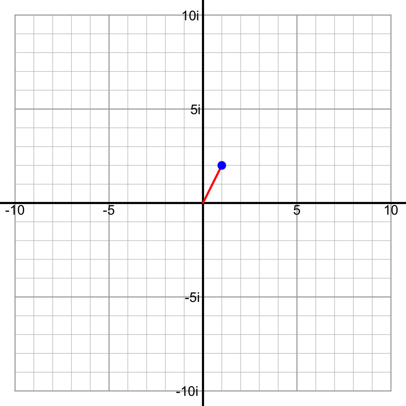

Calculate $|z|$, the [modulus](https://en.wikipedia.org/wiki/Absolute_value#Complex_numbers) of the complex number graphed above. *The tolerance is $\pm 0.01$.*

The horizontal (real) component is 1. The vertical (imaginary) component is 2. So,
$$z_1 = 1+2i$$

Use the formula.
$$|z_1| =
\sqrt{(1)^2+(2)^2}$$
$$|z_1| =
\sqrt{1+4}$$
$$|z_1| = \sqrt{5}
\approx 2.236068$$

Let $z$ be a complex number with integer components. It is graphed on a [complex plane](https://en.wikipedia.org/wiki/Complex_plane) below, along with a segment connecting it to the origin.

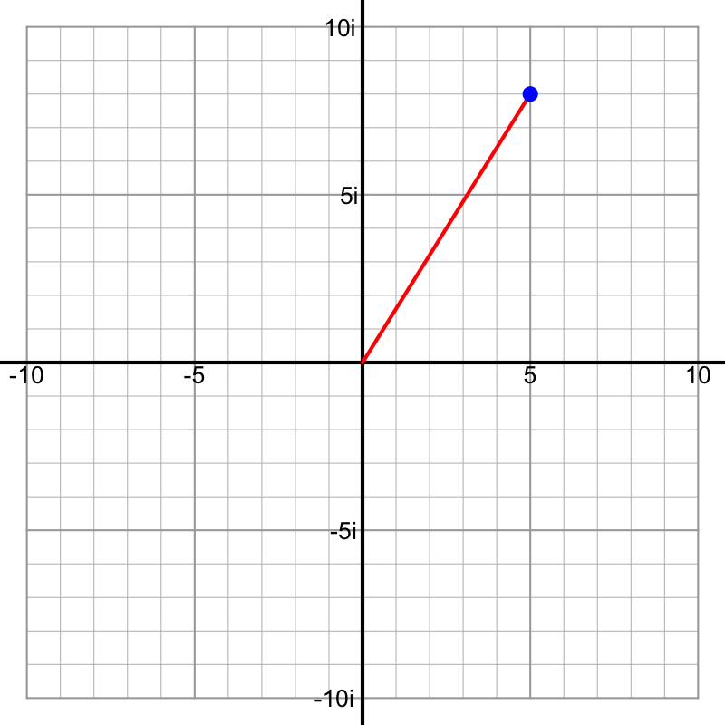

Calculate $|z|$, the [modulus](https://en.wikipedia.org/wiki/Absolute_value#Complex_numbers) of the complex number graphed above. *The tolerance is $\pm 0.01$.*

The horizontal (real) component is 5. The vertical (imaginary) component is 8. So,
$$z_1 = 5+8i$$

Use the formula.
$$|z_1| =
\sqrt{(5)^2+(8)^2}$$
$$|z_1| =
\sqrt{25+64}$$
$$|z_1| = \sqrt{89}
\approx 9.4339811$$

Let $z$ be a complex number with integer components. It is graphed on a [complex plane](https://en.wikipedia.org/wiki/Complex_plane) below, along with a segment connecting it to the origin.

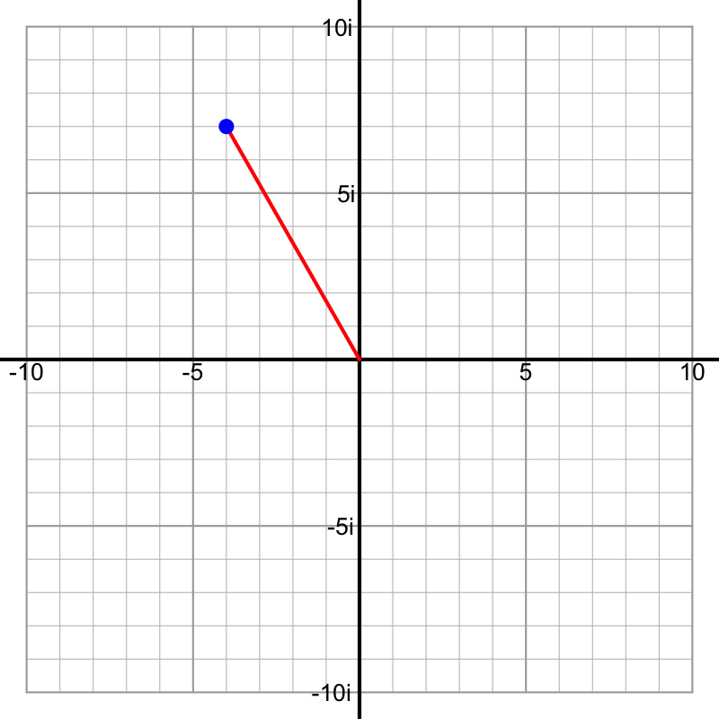

Calculate $|z|$, the [modulus](https://en.wikipedia.org/wiki/Absolute_value#Complex_numbers) of the complex number graphed above. *The tolerance is $\pm 0.01$.*

The horizontal (real) component is -4. The vertical (imaginary) component is 7. So,
$$z_1 =
-4+7i$$

Use the formula.
$$|z_1| =
\sqrt{(-4)^2+(7)^2}$$
$$|z_1| =
\sqrt{16+49}$$
$$|z_1| = \sqrt{65}
\approx 8.0622577$$

Let $z$ be a complex number with integer components. It is graphed on a [complex plane](https://en.wikipedia.org/wiki/Complex_plane) below, along with a segment connecting it to the origin.

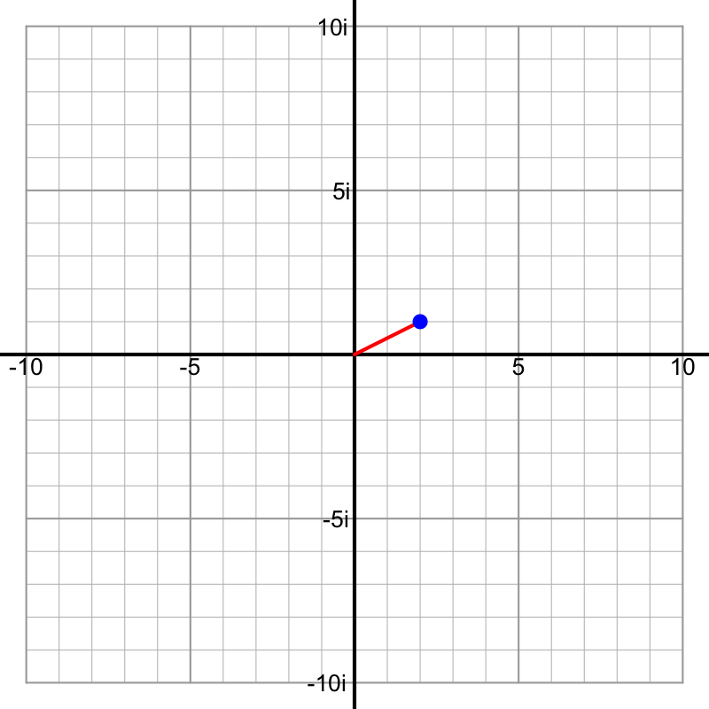

Calculate $|z|$, the [modulus](https://en.wikipedia.org/wiki/Absolute_value#Complex_numbers) of the complex number graphed above. *The tolerance is $\pm 0.01$.*

The horizontal (real) component is 2. The vertical (imaginary) component is 1. So,
$$z_1 = 2+i$$

Use the formula.
$$|z_1| =
\sqrt{(2)^2+(1)^2}$$
$$|z_1| =
\sqrt{4+1}$$
$$|z_1| = \sqrt{5}
\approx 2.236068$$

Let $z$ be a complex number with integer components. It is graphed on a [complex plane](https://en.wikipedia.org/wiki/Complex_plane) below, along with a segment connecting it to the origin.

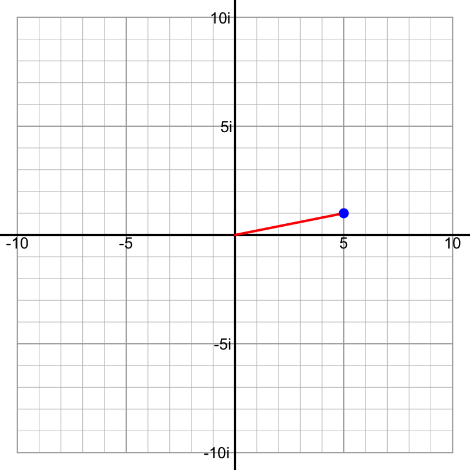

Calculate $|z|$, the [modulus](https://en.wikipedia.org/wiki/Absolute_value#Complex_numbers) of the complex number graphed above. *The tolerance is $\pm 0.01$.*

The horizontal (real) component is 5. The vertical (imaginary) component is 1. So,
$$z_1 = 5+i$$

Use the formula.
$$|z_1| =
\sqrt{(5)^2+(1)^2}$$
$$|z_1| =
\sqrt{25+1}$$
$$|z_1| = \sqrt{26}
\approx 5.0990195$$

Let $z$ be a complex number with integer components. It is graphed on a [complex plane](https://en.wikipedia.org/wiki/Complex_plane) below, along with a segment connecting it to the origin.

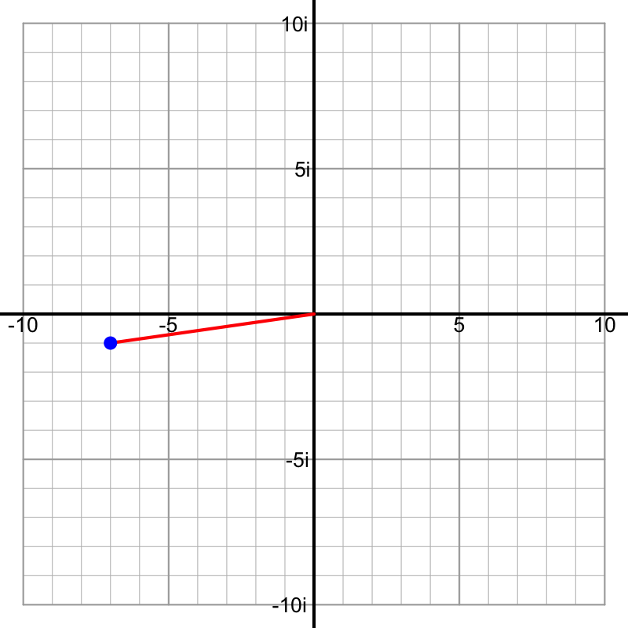

Calculate $|z|$, the [modulus](https://en.wikipedia.org/wiki/Absolute_value#Complex_numbers) of the complex number graphed above. *The tolerance is $\pm 0.01$.*

The horizontal (real) component is -7. The vertical (imaginary) component is -1. So,
$$z_1 =
-7-i$$

Use the formula.
$$|z_1| =
\sqrt{(-7)^2+(-1)^2}$$
$$|z_1| =
\sqrt{49+1}$$
$$|z_1| = \sqrt{50}
\approx 7.0710678$$

Let $z$ be a complex number with integer components. It is graphed on a [complex plane](https://en.wikipedia.org/wiki/Complex_plane) below, along with a segment connecting it to the origin.

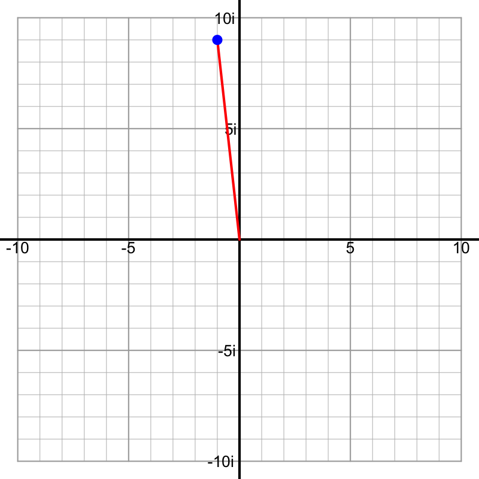

Calculate $|z|$, the [modulus](https://en.wikipedia.org/wiki/Absolute_value#Complex_numbers) of the complex number graphed above. *The tolerance is $\pm 0.01$.*

The horizontal (real) component is -1. The vertical (imaginary) component is 9. So,
$$z_1 =
-1+9i$$

Use the formula.
$$|z_1| =
\sqrt{(-1)^2+(9)^2}$$
$$|z_1| =
\sqrt{1+81}$$
$$|z_1| = \sqrt{82}
\approx 9.0553851$$

Let $z$ be a complex number with integer components. It is graphed on a [complex plane](https://en.wikipedia.org/wiki/Complex_plane) below, along with a segment connecting it to the origin.

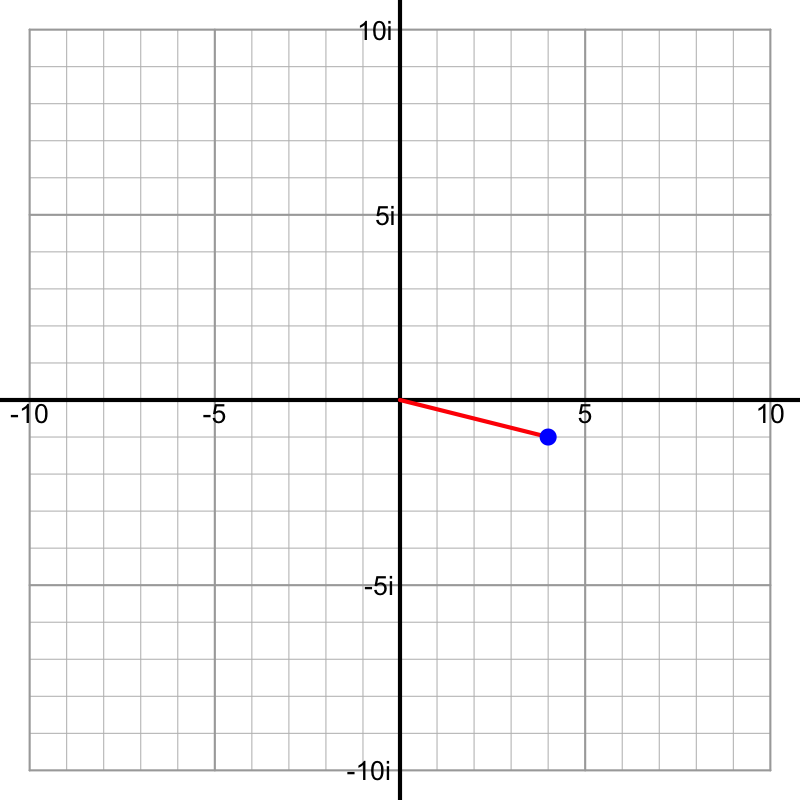

Calculate $|z|$, the [modulus](https://en.wikipedia.org/wiki/Absolute_value#Complex_numbers) of the complex number graphed above. *The tolerance is $\pm 0.01$.*

The horizontal (real) component is 4. The vertical (imaginary) component is -1. So,
$$z_1 = 4-i$$

Use the formula.
$$|z_1| =
\sqrt{(4)^2+(-1)^2}$$
$$|z_1| =
\sqrt{16+1}$$
$$|z_1| = \sqrt{17}
\approx 4.1231056$$

Let $z$ be a complex number with integer components. It is graphed on a [complex plane](https://en.wikipedia.org/wiki/Complex_plane) below, along with a segment connecting it to the origin.

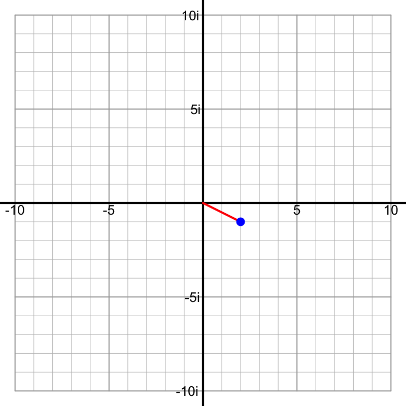

Calculate $|z|$, the [modulus](https://en.wikipedia.org/wiki/Absolute_value#Complex_numbers) of the complex number graphed above. *The tolerance is $\pm 0.01$.*

The horizontal (real) component is 2. The vertical (imaginary) component is -1. So,
$$z_1 = 2-i$$

Use the formula.
$$|z_1| =
\sqrt{(2)^2+(-1)^2}$$
$$|z_1| =
\sqrt{4+1}$$
$$|z_1| = \sqrt{5}
\approx 2.236068$$

Let $z$ be a complex number with integer components. It is graphed on a [complex plane](https://en.wikipedia.org/wiki/Complex_plane) below, along with a segment connecting it to the origin.

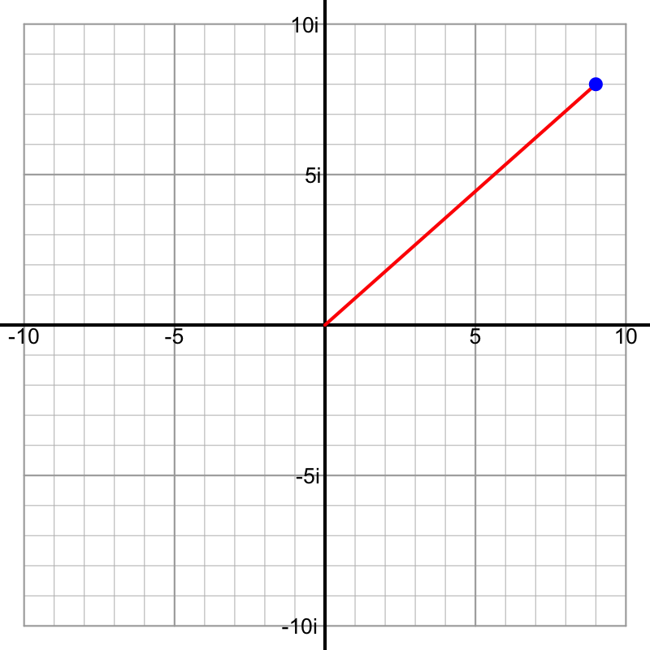

Calculate $|z|$, the [modulus](https://en.wikipedia.org/wiki/Absolute_value#Complex_numbers) of the complex number graphed above. *The tolerance is $\pm 0.01$.*

The horizontal (real) component is 9. The vertical (imaginary) component is 8. So,
$$z_1 = 9+8i$$

Use the formula.
$$|z_1| =
\sqrt{(9)^2+(8)^2}$$
$$|z_1| =
\sqrt{81+64}$$
$$|z_1| = \sqrt{145}
\approx 12.0415946$$

Define function $f$ with equation $f(x)~=~{4}x^{2}+{7}x-{9}$.

Evaluate $f(-2+3i)$.

$$f(-2+3i) ~=~
4(-2+3i)^2+7(-2+3i)-9$$

The most challenging part is squaring the complex input. Remember, raising to the power of 2 means multiplying by itself. When we multiply two complex numbers, we basically "FOIL".

$$(-2+3i)^2~\equiv~(-2+3i)(-2+3i)~\equiv~4-6i-6i+9i^2$$

Remember, $i^2=-1$.

$$(-2+3i)^2~\equiv~4-6i-6i-9$$

Combine like terms.

$$(-2+3i)^2~\equiv~-5-12i$$

So, now return to the full expression, replacing $(-2+3i)^2$ with $-5-12i$.

$$f(-2+3i) ~=~
4(-5-12i)+7(-2+3i)-9$$

Distribute.

$$f(-2+3i) ~=~
-20-48i-14+21i-9$$

Combine like terms.

$$f(-2+3i) ~=~ -43-27i$$

So, type your answer as `-43-27i`.

Define function $f$ with equation $f(x)~=~{6}x^{2}-{8}x+{5}$.

Evaluate $f(3+2i)$.

$$f(3+2i) ~=~
6(3+2i)^2-8(3+2i)+5$$

The most challenging part is squaring the complex input. Remember, raising to the power of 2 means multiplying by itself. When we multiply two complex numbers, we basically "FOIL".

$$(3+2i)^2~\equiv~(3+2i)(3+2i)~\equiv~9+6i+6i+4i^2$$

Remember, $i^2=-1$.

$$(3+2i)^2~\equiv~9+6i+6i-4$$

Combine like terms.

$$(3+2i)^2~\equiv~5+12i$$

So, now return to the full expression, replacing $(3+2i)^2$ with $5+12i$.

$$f(3+2i) ~=~
6(5+12i)-8(3+2i)+5$$

Distribute.

$$f(3+2i) ~=~ 30+72i-24-16i+5$$

Combine like terms.

$$f(3+2i) ~=~ 11+56i$$

So, type your answer as `11+56i`.

Define function $f$ with equation $f(x)~=~{5}x^{2}-{4}x+{8}$.

Evaluate $f(3+2i)$.

$$f(3+2i) ~=~
5(3+2i)^2-4(3+2i)+8$$

The most challenging part is squaring the complex input. Remember, raising to the power of 2 means multiplying by itself. When we multiply two complex numbers, we basically "FOIL".

$$(3+2i)^2~\equiv~(3+2i)(3+2i)~\equiv~9+6i+6i+4i^2$$

Remember, $i^2=-1$.

$$(3+2i)^2~\equiv~9+6i+6i-4$$

Combine like terms.

$$(3+2i)^2~\equiv~5+12i$$

So, now return to the full expression, replacing $(3+2i)^2$ with $5+12i$.

$$f(3+2i) ~=~
5(5+12i)-4(3+2i)+8$$

Distribute.

$$f(3+2i) ~=~ 25+60i-12-8i+8$$

Combine like terms.

$$f(3+2i) ~=~ 21+52i$$

So, type your answer as `21+52i`.

Define function $f$ with equation $f(x)~=~{-5}x^{2}+{9}x+{6}$.

Evaluate $f(2+3i)$.

$$f(2+3i) ~=~
-5(2+3i)^2+9(2+3i)+6$$

The most challenging part is squaring the complex input. Remember, raising to the power of 2 means multiplying by itself. When we multiply two complex numbers, we basically "FOIL".

$$(2+3i)^2~\equiv~(2+3i)(2+3i)~\equiv~4+6i+6i+9i^2$$

Remember, $i^2=-1$.

$$(2+3i)^2~\equiv~4+6i+6i-9$$

Combine like terms.

$$(2+3i)^2~\equiv~-5+12i$$

So, now return to the full expression, replacing $(2+3i)^2$ with $-5+12i$.

$$f(2+3i) ~=~
-5(-5+12i)+9(2+3i)+6$$

Distribute.

$$f(2+3i) ~=~ 25-60i+18+27i+6$$

Combine like terms.

$$f(2+3i) ~=~ 49-33i$$

So, type your answer as `49-33i`.

Define function $f$ with equation $f(x)~=~{-5}x^{2}+{4}x-{7}$.

Evaluate $f(2+3i)$.

$$f(2+3i) ~=~
-5(2+3i)^2+4(2+3i)-7$$

The most challenging part is squaring the complex input. Remember, raising to the power of 2 means multiplying by itself. When we multiply two complex numbers, we basically "FOIL".

$$(2+3i)^2~\equiv~(2+3i)(2+3i)~\equiv~4+6i+6i+9i^2$$

Remember, $i^2=-1$.

$$(2+3i)^2~\equiv~4+6i+6i-9$$

Combine like terms.

$$(2+3i)^2~\equiv~-5+12i$$

So, now return to the full expression, replacing $(2+3i)^2$ with $-5+12i$.

$$f(2+3i) ~=~
-5(-5+12i)+4(2+3i)-7$$

Distribute.

$$f(2+3i) ~=~ 25-60i+8+12i-7$$

Combine like terms.

$$f(2+3i) ~=~ 26-48i$$

So, type your answer as `26-48i`.

Define function $f$ with equation $f(x)~=~{2}x^{2}+{6}x-{9}$.

Evaluate $f(-5+4i)$.

$$f(-5+4i) ~=~
2(-5+4i)^2+6(-5+4i)-9$$

The most challenging part is squaring the complex input. Remember, raising to the power of 2 means multiplying by itself. When we multiply two complex numbers, we basically "FOIL".

$$(-5+4i)^2~\equiv~(-5+4i)(-5+4i)~\equiv~25-20i-20i+16i^2$$

Remember, $i^2=-1$.

$$(-5+4i)^2~\equiv~25-20i-20i-16$$

Combine like terms.

$$(-5+4i)^2~\equiv~9-40i$$

So, now return to the full expression, replacing $(-5+4i)^2$ with $9-40i$.

$$f(-5+4i) ~=~
2(9-40i)+6(-5+4i)-9$$

Distribute.

$$f(-5+4i) ~=~
18-80i-30+24i-9$$

Combine like terms.

$$f(-5+4i) ~=~ -21-56i$$

So, type your answer as `-21-56i`.

Define function $f$ with equation $f(x)~=~{5}x^{2}+{6}x-{8}$.

Evaluate $f(-3+2i)$.

$$f(-3+2i) ~=~
5(-3+2i)^2+6(-3+2i)-8$$

The most challenging part is squaring the complex input. Remember, raising to the power of 2 means multiplying by itself. When we multiply two complex numbers, we basically "FOIL".

$$(-3+2i)^2~\equiv~(-3+2i)(-3+2i)~\equiv~9-6i-6i+4i^2$$

Remember, $i^2=-1$.

$$(-3+2i)^2~\equiv~9-6i-6i-4$$

Combine like terms.

$$(-3+2i)^2~\equiv~5-12i$$

So, now return to the full expression, replacing $(-3+2i)^2$ with $5-12i$.

$$f(-3+2i) ~=~
5(5-12i)+6(-3+2i)-8$$

Distribute.

$$f(-3+2i) ~=~
25-60i-18+12i-8$$

Combine like terms.

$$f(-3+2i) ~=~ -1-48i$$

So, type your answer as `-1-48i`.

Define function $f$ with equation $f(x)~=~{4}x^{2}+{5}x-{6}$.

Evaluate $f(3-2i)$.

$$f(3-2i) ~=~
4(3-2i)^2+5(3-2i)-6$$

The most challenging part is squaring the complex input. Remember, raising to the power of 2 means multiplying by itself. When we multiply two complex numbers, we basically "FOIL".

$$(3-2i)^2~\equiv~(3-2i)(3-2i)~\equiv~9-6i-6i+4i^2$$

Remember, $i^2=-1$.

$$(3-2i)^2~\equiv~9-6i-6i-4$$

Combine like terms.

$$(3-2i)^2~\equiv~5-12i$$

So, now return to the full expression, replacing $(3-2i)^2$ with $5-12i$.

$$f(3-2i) ~=~
4(5-12i)+5(3-2i)-6$$

Distribute.

$$f(3-2i) ~=~ 20-48i+15-10i-6$$

Combine like terms.

$$f(3-2i) ~=~ 29-58i$$

So, type your answer as `29-58i`.

Define function $f$ with equation $f(x)~=~{2}x^{2}+{9}x+{5}$.

Evaluate $f(-6-3i)$.

$$f(-6-3i) ~=~
2(-6-3i)^2+9(-6-3i)+5$$

The most challenging part is squaring the complex input. Remember, raising to the power of 2 means multiplying by itself. When we multiply two complex numbers, we basically "FOIL".

$$(-6-3i)^2~\equiv~(-6-3i)(-6-3i)~\equiv~36+18i+18i+9i^2$$

Remember, $i^2=-1$.

$$(-6-3i)^2~\equiv~36+18i+18i-9$$

Combine like terms.

$$(-6-3i)^2~\equiv~27+36i$$

So, now return to the full expression, replacing $(-6-3i)^2$ with $27+36i$.

$$f(-6-3i) ~=~
2(27+36i)+9(-6-3i)+5$$

Distribute.

$$f(-6-3i) ~=~
54+72i-54-27i+5$$

Combine like terms.

$$f(-6-3i) ~=~ 5+45i$$

So, type your answer as `5+45i`.

Define function $f$ with equation $f(x)~=~{-2}x^{2}+{4}x-{8}$.

Evaluate $f(3+5i)$.

$$f(3+5i) ~=~
-2(3+5i)^2+4(3+5i)-8$$

The most challenging part is squaring the complex input. Remember, raising to the power of 2 means multiplying by itself. When we multiply two complex numbers, we basically "FOIL".

$$(3+5i)^2~\equiv~(3+5i)(3+5i)~\equiv~9+15i+15i+25i^2$$

Remember, $i^2=-1$.

$$(3+5i)^2~\equiv~9+15i+15i-25$$

Combine like terms.

$$(3+5i)^2~\equiv~-16+30i$$

So, now return to the full expression, replacing $(3+5i)^2$ with $-16+30i$.

$$f(3+5i) ~=~
-2(-16+30i)+4(3+5i)-8$$

Distribute.

$$f(3+5i) ~=~ 32-60i+12+20i-8$$

Combine like terms.

$$f(3+5i) ~=~ 36-40i$$

So, type your answer as `36-40i`.